# Graphiques avec ggplot2

## Personnalisations avancées

Avec la fonction `theme()`, qui a une syntaxe bien particulière : chaque élément doit être spécifié selon sa nature.

- Pour changer la taille, la police, la couleur d’élément de type “texte”, on utilise `element_text(size=, colour = "", family = "")`
- Pour changer la couleur et la taille d’une ligne, on utilise `element_line(colour=“”, size=)`
- Pour personnaliser la couleur du fond, on utilise `element_rect(fill = "")`

## Ce que l’on peut changer avec `theme()`

- `axis.title`, `axis.title.x`, `axis.title.y` : taille, police, couleur, …
- `axis.text`, `axis.text.x`, `axis.text.y` : taille, police, couleur, …
- `axis.ticks`, `axis.ticks.x`, `axis.ticks.y`
- `axis.line`, `axis.line.x`, `axis.line.y`
- `panel.background` : couleur
- `panel.grid.major`, `panel.grid.minor` : couleur, taille
- `legend.text`: taille, police, couleur
- `legend.position`
- `plot.title` : taille, police, couleur

## Nuages de points

## Avec `geom_point`

Cette géométrie nécessite des paramètres esthétiques de position (en \(x\) et \(y\)), et accepte optionnellement des paramètres esthétiques de taille, couleur et forme.

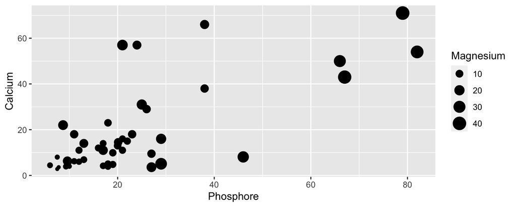

```r
ggplot(fruits, aes(x = Phosphore, y = Calcium, size = Magnesium)) +
  geom_point()
```

## Paramètres esthétiques

Lorsqu’ils sont spécifiés dans la fonction `aes()`, ces paramètres appliquent les valeurs d’une variable à une caractéristique des objets graphiques tracés par les géométries.

- `color` ou `colour` : couleur du point
- `fill` : couleur de remplissage
- `size` : taille
- `shape` : forme
- `alpha` : transparence
- `linetype` : type de ligne
- `label` : étiquettes

Lorsqu’ils sont appliqués en dehors de la fonction `aes()`, leur comportement est plus général !

## Exemple

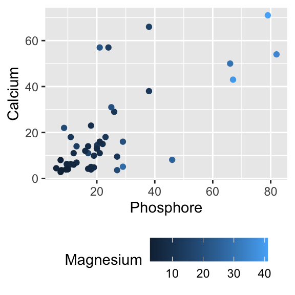

```r
ggplot(fruits,
       aes(x = Phosphore, y = Calcium,
           color = Magnesium)) +
  geom_point() +
  theme(legend.position = "bottom")
```

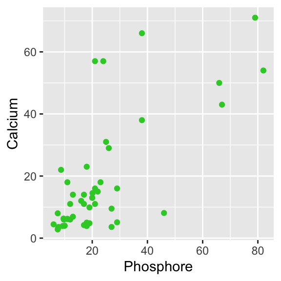

```r
ggplot(fruits,
    aes(x = Phosphore, y = Calcium)) +
  geom_point(color = "limegreen")
```